# Coursework Report

*N* removed NAs: 3

*N* removed typo: 1

*N* removed <18: 18

*N* total clean: 128

| Group | *N* | *M*<sub>age</sub> | *M*<sub>rating</sub> |
| --- | --- | --- | --- |
| Control | 71 | 20.90 | 5.93 |
| Experim | 57 | 20.63 | 5.02 |

**Main analysis results**

*t*(126) = 6.57, *p* < .001

[interactive chart not shown]

[figure not shown]

[interactive chart not shown]

# Coursework Report

Analysing Data, Spring 2020

# Method

## Participants

The study was initially conducted on a sample of 150 female participants (*M*<sub>age</sub> = 20.15, *SD*<sub>age</sub> = 2.68, range = 11 - 28). Of these, 18 participants were underage, 3 had missing values in their data, and 1 mistyped their age. As a result, these 22 total participants had their data removed from the final study. The remaining 128 participants (*M*<sub>age</sub> = 20.78, *SD*<sub>age</sub> = 2.13, range = 18 - 28) were grouped into one of two conditions: red (experimental) or white (control). Table 1 shows the number and age of participants in each condition.

Table 1: *Descriptive statistics by Colour Condition*

| Condition | *N* | % | *M*<sub>age</sub> | *SD*<sub>age</sub> |
| --- | --- | --- | --- | --- |
| White | 71 | 55.47 | 20.90 | 2.22 |
| Red | 57 | 44.53 | 20.63 | 2.02 |

## Design

This experiment used an independent measures design to examine the hypothesis that colour influences women’s perceived attraction to men. The independent categorical variable was the colour condition. This had two levels: whether participants viewed the man in a red (experimental) or white (control) frame. Here, colour was the predictor in the experiment. The dependant variable and outcome was the mean attractiveness rating, measured via three items also used in Elliot et al.’s study: “How attractive do you think this person is?” “How pleasant is this person to look at?” and “If I were to meet the person in this picture face to face, I would think he is attractive.” These measures were all rated using a 9-point scale, ranging from 1 (*not at all*) to 9 (*extremely*). The results were then averaged to form a mean composite score, where a higher score out of 9 represented higher perceived attractiveness and a lower score represented lower perceived attractiveness. It was hypothesised that viewing either a red or white colour frame around an image of a moderately attractive man would significantly influence mean attractiveness ratings from women. An independent-samples *t*-test was used to test this hypothesis.

# Results

We used an independant-samples *t*-test to examine whether female participants would rate a man’s attractiveness significantly differently depending on whether the man was viewed on a red or white colour frame. Participants in the white condition gave the man an average perceived attractiveness rating of 5.93/9, whilst participants in the red condition gave an average rating of 5.02/9. Table 2 shows a summary of the data.

The analysis revealed that this difference in mean attractiveness ratings of the red versus white colour groups was statistically significant (*M*<sub>diff</sub> = 0.91, 95% CI [0.63, 1.18], *t* (126) = 6.57, *p* < .001). This means that, since a higher score indicates higher perceived attractiveness, the man in the white frame was rated as significantly more attractive than the man in the red frame. We can therefore reject the null hypothesis and conclude that it is likely that colour does make a difference to perceiped attractiveness ratings (see Figure 1).

However, in contrast to Elliot et al’s prediciton of a ‘red effect’, a ‘white effect’ was observed in our analysis, where the colour white over the colour red appeared to increase perceived attractiveness.

Table 2: *Composite score by colour condition*

| Condition | Composite score of attractiveness *M* | Composite score of attractiveness *SD* | Composite score of attractiveness *Min* | Composite score of attractiveness *Max* |
| --- | --- | --- | --- | --- |
| White | 5.93 | 0.81 | 4.00 | 8.00 |
| Red | 5.02 | 0.73 | 3.67 | 6.67 |

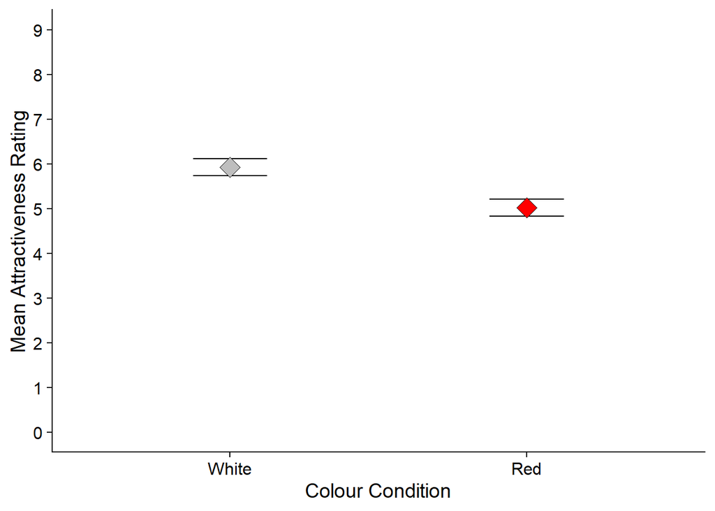

# Discussion

In this study a close replication of the first experiment in Elliot el al’s (2010) experimental series was conducted. Here, women viewing a man presented in a red frame or wearing red apparel rated him to be more attractive than women viewing the same man presented in other colours. This is proposed to be due to a complex interplay between social conditioning and innate biological preferences, which results in the colour red enhancing women’s perception of a man’s status.

Although the results of the present study support the hypothesis that colour makes a difference to perceived attractiveness, they contradict the findings of the original study. Here the white over the red frame is found to significantly increase mean perceived attractiveness ratings of men. This single result might appear less convincing than the original ‘red-effect’ finding, which was repeatedly replicated over a series of 12 experiments hereby implying reliability (Elliot et al, 2010). However, Francis (2013) argued that, due to the estimated low power of the experiments, Elliot et al’s perfect replications might actually be an indication of publication bias. The results could therefore be considered unreliable and unscientific. In response to this criticism, Elliot and Maier (2013) ran a replication of their third experiment using a sample size four times that of the original, only to find no significant red colour-effect. Similarly, further experiments by independent investigators including Hesslinger et al (2015) and Wen et al (2014) also failed to find evidence for this red-effect. Therefore, the results of the present study, which had a significantly larger sample size than the original, might actually serve to further question the robustness and validity of the red-effect as a whole, as well as further challenging the reliability of the original Elliot et al study.

Elliot et al (2010) posited that the colour red is associated with high levels of testosterone, which are associated with high-status and success. However, testosterone is also related to other personality traits including aggression, dominance and hostility (Batrinos, 2012), which are potential turn offs for a woman seeking a partner (Wen et al, 2014) and could thus explain the reduced attractiveness rating found in the red condition. These perceived negative characteristics have been found to be most prominent in men with neutral facial expressions (Hareli et al, 2009), similar to the expression of the man used in this study. Here it seems possible that, had the man been smiling, a positive red-effect would have been found. To establish if facial expression is a mediating factor in the red colour-effect, multiple images of the man with various facial expressions should have been included in both conditions.

Assuming that Elliot et al (2010) are correct in their claim that the colour red implies high status, this status might not increase attractiveness. Studies have shown that women’s preference for high status is weaker in less patriarchal societies as well as in women with less traditional sex-role expectations (Eagly and Wood, 1999). Further, Elliot et al (2010) claim both that women are biologically predisposed to favour high status as this allows for more resources and safety during pregnancy and, that high-status men have more sex with more women. In the case of a woman who is looking for a long-term relationship and values faithfulness and stability over the possibility of resources, the colour red might be deemed less attractive as it conveys infidelity. Here, many factors which were not controlled for in the present study may have mediated the resulting colour-effect, including the female participant’s views on gender roles and her own status and financial position, as well as what she values in a partner, including whether the participant is interested in long-term or short-term relationships, and whether she is single or in a relationship at the time of the experiment.

In their study of the red-effect on men viewing women, Peperkoorn et al (2016) found a slight but insignificant white effect over both black and red. Similarly, Guéguen (2011) found that white had a greater effect on attraction ratings than both blue and green. This implies that rather than a negative red-effect, the results of this study may in fact reflect a positive white-effect, where white increases the perceived attractiveness of men. White carries connotations of morality and honesty (Peperkoorn et al, 2016)- traits which might be important to women looking for a partner. Further evidence also suggests that brightness over darkness is associated with goodness (Meier et al, 2004), suggesting that, rather than a specific colour-effect, the higher attractiveness ratings found in the white condition might be the result of a brightness-effect instead.

However, the present study doesn’t provide any insight into whether a negative red-effect or a positive white-effect was responsible for the results, and so it cannot conclusively be said that either effect exists. It would have been a good idea to use more colour conditions in the study, including colours equal to red in brightness, to better establish whether one colour condition produces significantly higher or lower attractiveness ratings, or whether all colours produce their own significant colour-effects. Further, the experimental-causal-chain mediation approach, as utilised by Elliot et al (2010), would have been helpful in establishing whether red and white are in fact related to perceptions of status/aggression and goodness, respectively, and whether these impact on perceived attractiveness, to further unpack the meaning of the results.

The majority of studies investigating colour-effects in attraction utilise a between-subjects design, where confounding variables and individual variability might weaken results. Further research should use a combination of both within- and between- subjects designs, to control for these variables and ensure that results are valid. In addition, self-reporting measures like the items used in this experiment are likely influenced by participants own view of themselves and their social desirability, especially relating to intimate information about attraction (Wen et al, 2014). Here, biological measures of attraction including heartrate and skin conductance used alongside self-reporting measures, would be useful in increasing validity and reliability of results.

Future research should utilise more images of different men in each colour condition. Not only would this increase the ecological validity of the experiment by replicating some of the variety of faces and bodies we experience in the real world, but studies have also shown that colour-effects are moderated by factors including attractiveness (Wen et al, 2014). Depending on the personal preferences of the female participant, the man in this study may have not been considered attractive enough for the red frame to have any enhancing effects, so using more images of men who embody different ‘types’ might be useful to counteract this. In addition, Wen et al (2014) found that masculinity moderates the red-effect in men. Here the colour red is less effective in increasing attractiveness in less masculine men, where a lack in masculine features implies reduced testosterone and status. Although a moderately attractive man was used in this study, this does not necessarily imply moderate masculinity, which might be another contributing factor in the lack of a red-effect in the results.

In conclusion, although red and white colour frames seem to influence the way women react to images of a man, there is no way to gauge whether this is the result of a positive white-effect or a negative red-effect, or a combination of both. It seems that the colour-effects are likely moderated by multiple factors including the female participant’s relationship status, social desirability and gender role-expectations, as well as the man’s facial expression and masculine features. The existing studies do not provide enough robust evidence to establish the exact effects of either red or white on perceived attractiveness. This could if at all only be achieved through continued vigorous testing of the hypothesis, via multiple replications utilising more colour conditions and larger sample sizes.

# References

Batrinos, M. L. (2012). Testosterone and aggressive behavior in man. International Journal of Endocrinology & Metabolism, 10(3), 563–568. https://doi.org/10.5812/ijem.3661

Eagly, A. H., & Wood, W. (1999a). The origins of sex differences in human behavior: Evolved dispositions versus social roles. American Psychologist, 54(6), 408–423. https://doi.org/10.1037/0003-066X.54.6.408

Elliot, A. J., & Maier, M. A. (2013). The red-attractiveness effect, applying the Ioannidis and Trikalinos (2007b) test, and the broader scientific context: A reply to Francis (2013). Journal of Experimental Psychology: General, 142(1), 297–300. https://doi.org/10.1037/a0029592

Francis, G. (2013). Publication bias in “Red, rank, and romance in women viewing men,” by Elliot et al. (2010). Journal of Experimental Psychology: General, 142(1), 292–296. https://doi.org/10.1037/a0027923

Guéguen, N. (2012). Color and Women Attractiveness: When Red Clothed Women Are Perceived to Have More Intense Sexual Intent. The Journal of Social Psychology, 152(3), 261–265. https://doi.org/10.1080/00224545.2011.605398

Hareli, S., Shomrat, N., & Hess, U. (2009). Emotional versus neutral expressions and perceptions of social dominance and submissiveness. Emotion, 9(3), 378–384. https://doi.org/10.1037/a0015958

Hesslinger, V. M., Goldbach, L., & Carbon, C.-C. (2015). Men in red: A reexamination of the red-attractiveness effect. Psychonomic Bulletin & Review, 22(4), 1142–1148. https://doi.org/10.3758/s13423-015-0866-8

Meier, B. P., Robinson, M. D., & Clore, G. L. (2004). Why Good Guys Wear White: Automatic Inferences About Stimulus Valence Based on Brightness. Psychological Science, 15(2), 82–87. https://doi.org/10.1111/j.0963-7214.2004.01502002.x

Pazda, A. D., Elliot, A. J., & Greitemeyer, T. (2012). Sexy red: Perceived sexual receptivity mediates the red-attraction relation in men viewing woman. Journal of Experimental Social Psychology, 48(3), 787–790. https://doi.org/10.1016/j.jesp.2011.12.009

Peperkoorn, L. S., Roberts, S. C., & Pollet, T. V. (2016). Revisiting the Red Effect on Attractiveness and Sexual Receptivity: No Effect of the Color Red on Human Mate Preferences. Evolutionary Psychology, 14(4), 147470491667384. https://doi.org/10.1177/1474704916673841

Wen, F., Zuo, B., Wu, Y., Sun, S., & Liu, K. (2014). Red is Romantic, but Only for Feminine Females: Sexual Dimorphism Moderates Red Effect on Sexual Attraction. Evolutionary Psychology, 12(4), 147470491401200. https://doi.org/10.1177/147470491401200404